# Average and multithreshold approach with and w/o complementarity

This script produces:

- Figure 1

```r
library(ggplot2)
library(Cairo)
library(grid)
library(cowplot)
library(dplyr)
library(tidyr)
library(corrplot)
library(magrittr)
library(multifunc)
library(viridis)

source("Multifunc_simulations_functions.R")
```

### Simulate diversity experiment

In this script we set up the simulations for the null expectation of the new multifunctionality metrics and the average approach:

- the average multifunctionality approach
- functional evenness
- new_multifunc

For this (and all other) simulations we set a number of species with the `specnum` parameter and a number of functions these species perform with the `funcnum` parameter. The function values for each species and functions are then drawn at random from a chosen distribution set by the `distribution` parameter. See `?Distributions` for possible choices and the required parameters. The default is a uniform distribution in the interval [0,1].

With the species and function values defined, we simulate a diversity experiment where

- we have 1 : `specnum` richness levels
- we have all possible combinations at each level (or a defined maximum of unique species combinations- set with `maxrep`; recommended for `specnum` > 12)
- we need to choose a method for computing a mixture function value.

The possible methods are:

- `av` for average. Here the mixture values at each diversity level are the unweighted single - species function values. So simply the mean (or average) value of the community.
- `comp` for complementarity. Here one, several or all functions are multiplied with a complementary factor before the average is calculated. The complementary factor is always a saturating function of the richness level of the form:

$$compfac = CF * ( 1 - ( 1 - \frac{1}{CF} ) * exp{ ( 1 - Richness ^ r )}$$

- `CF` : maximum value for the complementary factors as $S \to \inf$
- `r` *growthrate* i.e. the rate at which `compfac` grows to `CF`
- `compfunc` : the functions subjected to complementarity Either “all” or a subset of `func.names`

To make the analysis reproducible we can set a seed with `set.seed.

### Draw function values for all species

`FunctionValue` takes three main arguments, `specnum`, `funcnum` and `distribution` and returns a data-frame with function values for all species and functions.

** If you change the distribution you have to change the distribution paramters in `FunctionValue`**

```r
# set seed to replicate analysis:
set.seed(999)

# number of species
specnum <- 12

# number of functions
funcnum <- 9

# distribution from which to draw function values
distribution = "rlnorm"

#DF <- data.frame(seed = rep(NA, 100), mean = NA)


# create function matrix
FuncMat <- FunctionValue(specnum,funcnum, distribution, meanlog = 1, sdlog = 0.5)
```

### Plot function values and function correlations

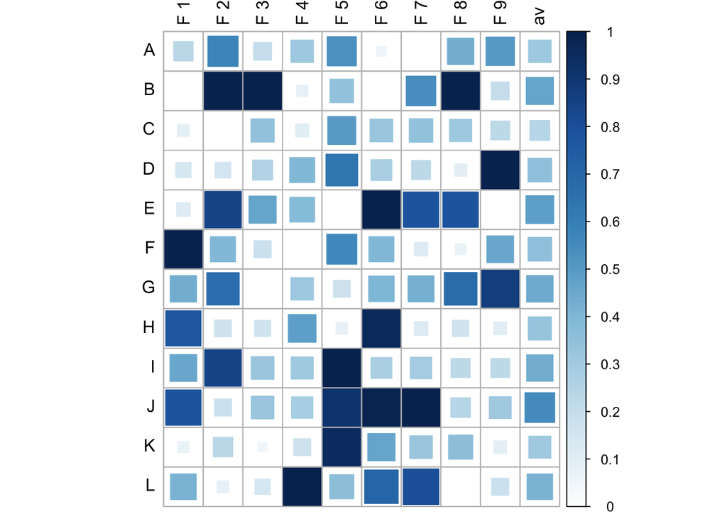

```r
FuncMat_plot <-
  FuncMat %>%
  group_by(Functions) %>%
  mutate(Funcval = (Funcval - min(Funcval)) / (max(Funcval) - min(Funcval))) %>%
  spread(Functions, Funcval) %>%
  select(-Species)


FuncMat_plot %>%
  mutate(av = rowMeans(.)) %>%
  as.matrix() %>%
  set_rownames(unique(FuncMat$Species)) %>%
  corrplot( is.corr = F, tl.col = "black", cl.ratio = 0.2,
           cl.length = 11, method="square")
```

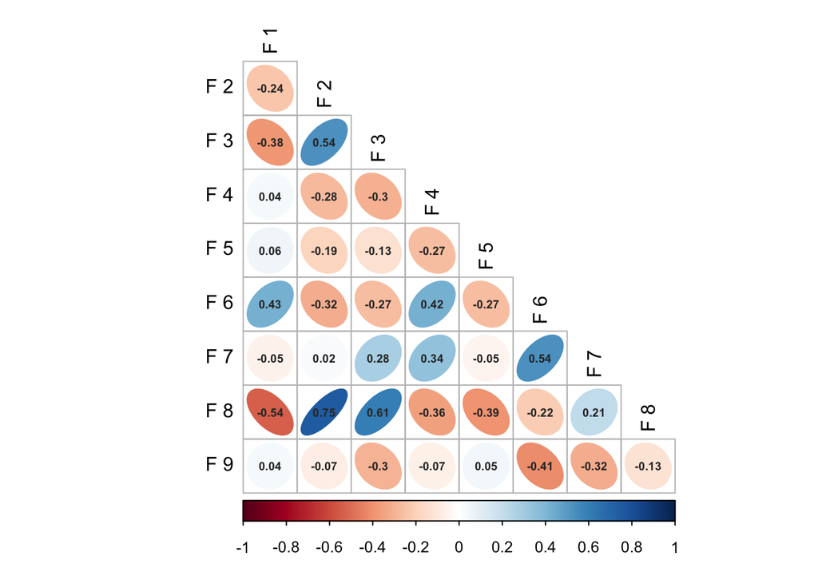

```r
FuncMat_plot %>% cor %>%
  corrplot(type = "lower", tl.col = "black", cl.ratio = 0.2,
           cl.length = 11, number.cex = 0.6, addCoef.col = "#323232", diag = F, method="ellipse")
```

## Scenario 1 - no diveristy effect on any single function

### Simulate diversity experiment

- `SpeciesMatrix` takes two arguments, `specnum`and `maxrep` and generates a *plot x species* matrix where each row is a *plot* and each column a *species*. Cell values are 0 or 1 and indicate which species are present in which plot. If `maxrep` is higher than `choose(specnum, floor(specnum/2))` (i.e. choose(12,6) = 924 possible combinations at richness level 6 for 12 species) all unique species combinations are simulated at each richness level. If `maxrep` is set to a lower number, a maximum of `maxrep` unique combinations are simulated for each richness level.
- `AverageFunction` takes the out put of `SpeciesMatrix` and `FunctionValue`, i.e. the plot x species matrix and the species - function data-frame simulated above, to calculate plot-wise functioning for all plots, given the chosen method (`av`or `comp`)

```r
# code takes ~5 min to run for 15 species. Set to lower value for higher number of species!

maxrep <- choose(specnum, floor(specnum/2))
#maxrep <- 500

# simulate plot x species matrix
SpecMat <- SpeciesMatrix(specnum = specnum, maxrep = maxrep)

# select method and additional parameters if appropriate by setting the `if` statement to `TRUE`
if (TRUE) {method = "av"}

if (FALSE) {method = "comp"
            CF = 3
            compfunc = c("F 1", "F 6")
            r = 0.25}


# Average function
AvFunc <- AverageFunction(SpecMat, FuncMat,
                          method = method,
                          CF = CF,
                          compfunc = compfunc,
                          r = r)
```

### Standardize function values

There are two main ways to standardize the function values:

- between 0 and 1 with $x_{stand} = \frac{x - min(x)}{max(x) - min(x)}$ *this standardization stretches the function values artifically between 0 and 1 and is likely to skew the evenness. We should discourage it as Lars and I did previously*
- by the maximum with $x_{stand} = \frac{x}{max(x)}$

*we should briefly discuss z-cores as they are common (i.e. in that they don’t work becaucse of frequencies (writing it down to think about it) and also standardization around 0 takes away the meaning of 0 = no functioning)*

```r
# extract function names
func.names <- as.character( unique( FuncMat$Functions))

# standardize by maximum
 AvFunc[,func.names] <- apply(AvFunc[,func.names], 2, function(x) {x/max(x)})

# alternative standardize between 0 and 1
# AvFunc[,func.names] <- apply(AvFunc[,func.names], 2, function(x) {(x - min(x)) / (max(x) - min(x))})
```

### Plot single function values

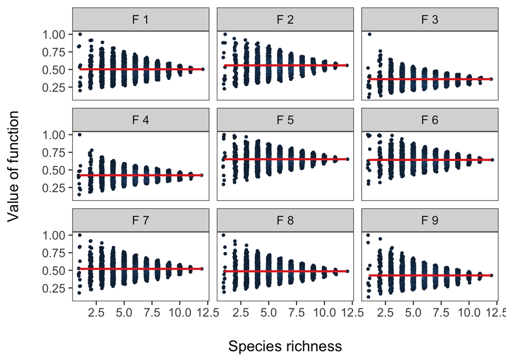

```r
AvFunc_long <- gather(AvFunc[, -c(1:specnum)], Function, FuncVal, -Richness)

SingleFunc <- AvFunc_long %>%
  mutate(FuncVal = round(FuncVal,3)) %>%
  group_by(Richness, Function, FuncVal) %>%
  summarize(n = n()) %>%
  ggplot(., aes(x=Richness, y=FuncVal, colour = n))+
  geom_point( size = 1, position = position_jitter(width = 0.1))+
  facet_wrap(~Function)+
  theme_bw(base_size=15)+
  stat_smooth(data = AvFunc_long, aes(x = Richness, y = FuncVal), method="lm", colour = "#de2d26") +
  xlab("\nSpecies richness") +
  ylab("Value of function\n") +
  theme(panel.grid = element_blank(), legend.position = "none")

SingleFunc
```

### Average approach for multifunctionality

- Multifunctionality is calculated as the average value of the standardized single functions.

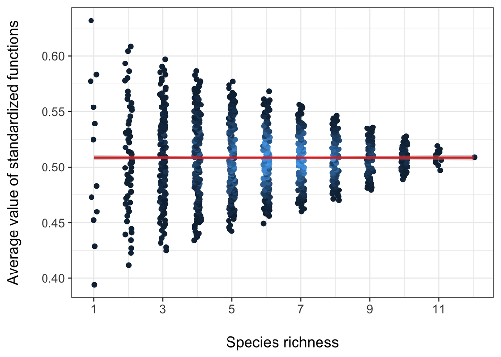

```r
# add averaged multifunctional index
AvFunc$meanFunction <- rowMeans(AvFunc[,func.names])

# plot
AverageFunc <-
  AvFunc %>%
  select(Richness, meanFunction) %>%
  mutate(meanFunction = round(meanFunction,3)) %>%
  group_by(Richness, meanFunction) %>%
  summarize(n = n()) %>%
  ggplot(., aes(x=Richness, y=meanFunction, colour = n))+
  geom_point(size = 2, position = position_jitter(width = 0.1))+
    theme_bw(base_size=15)+
    stat_smooth(data = AvFunc, aes(x = Richness, y = meanFunction), method="lm", colour = "#de2d26") +
    xlab("\nSpecies richness") +
    ylab("Average value of standardized functions\n")+
  theme(legend.position = "none")+
   # scale_y_continuous(limits = c(0.25,0.75))+
    scale_x_continuous(breaks = seq(1,15,2))

AverageFunc
```

### new multifunctionlity metric

*code copied and adapted from multifunc_new.Rmd*

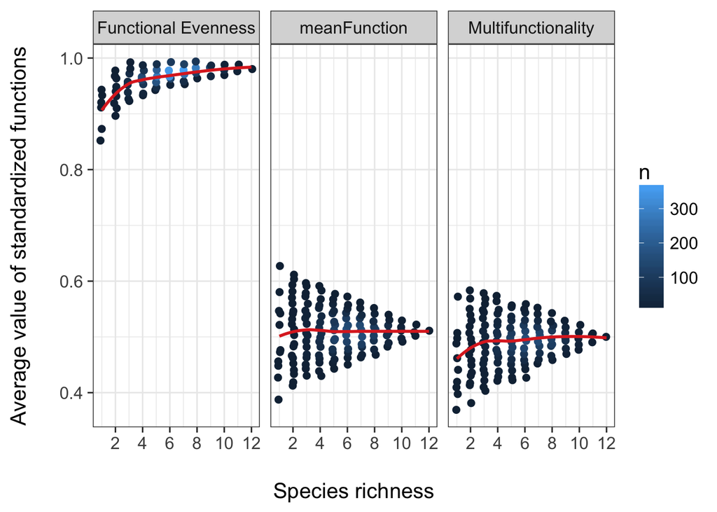

```r
#now evenness
AvFunc[["Functional Evenness"]] <- AvFunc %>% funcEven(func.names)

#Now our multifunctionality metric - I could have
#done this as a product, but I'm guessing people will want a function
AvFunc$Multifunctionality <- AvFunc %>% getMF(func.names)

Multifunc_new <-
  AvFunc %>%
  select(Richness, meanFunction, `Functional Evenness`, Multifunctionality) %>%
  gather(index, value, -Richness) %>%
  mutate(value = round(value, 2)) %>%
  group_by(value, Richness, index) %>%
  summarise(n = n()) %>%
  ggplot(., aes(x=Richness, y=value, colour = n))+
  geom_point(size = 2,
             position = position_jitter(width = 0.1))+
    theme_bw(base_size=15)+
    stat_smooth( colour = "#de2d26", se = F) +
    facet_wrap(~index)+
    xlab("\nSpecies richness") +
    ylab("Average value of standardized functions\n")+
 # theme(legend.position = "none")+
   # scale_y_continuous(limits = c(0.25,0.75))+
    scale_x_continuous(breaks = seq(0,12,2))

Multifunc_new
```

with effective number of functions

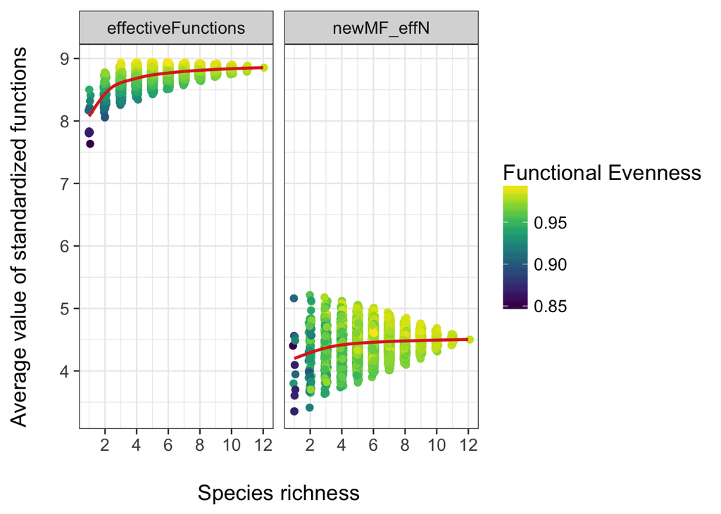

```r
AvFunc[["effectiveFunctions"]] <- AvFunc[,func.names] %>% multifunc::eff_div(q = 1)
AvFunc <- mutate(AvFunc, newMF_effN = effectiveFunctions * meanFunction)

Multifunc_new <-
  select(AvFunc, Richness, effectiveFunctions, newMF_effN, `Functional Evenness`) %>%
  gather(index, value, -Richness, -`Functional Evenness`) %>%
  ggplot(., aes(x=Richness, y=value, colour = `Functional Evenness`))+
  geom_point(size = 2,
             position = position_jitter(width = 0.1))+
  facet_wrap(~index)+
    theme_bw(base_size=15)+
    stat_smooth( colour = "#de2d26", se = F) +
    xlab("\nSpecies richness") +
    ylab("Average value of standardized functions\n")+
 # theme(legend.position = "none")+
   # scale_y_continuous(limits = c(0.25,0.75))+
    scale_x_continuous(breaks = seq(0,12,2))+
  scale_color_viridis()

Multifunc_new
```

correlation between average MF and MF_new

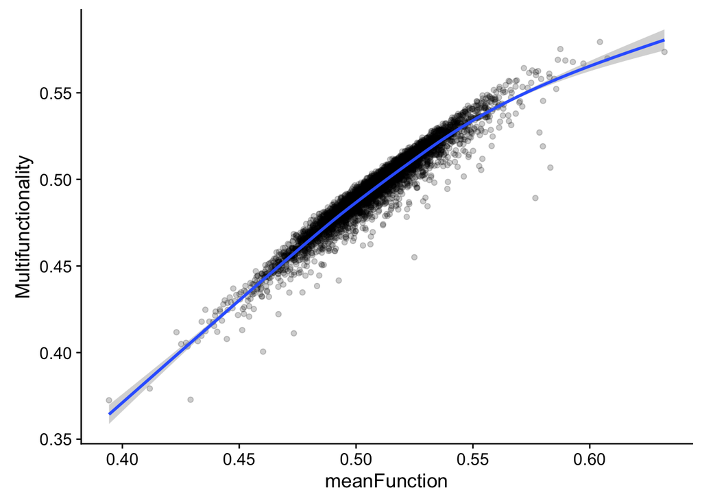

```r
ggplot(AvFunc, aes(x = meanFunction, y = Multifunctionality))+
  geom_point(alpha = 0.2)+
  geom_smooth()
```

## Scenario 2 - complementarity effect on 2 functions

Exact same code as above, but with the `method = "comp"` chosen to simulate complementary for two functions.

### Simulate diversity experiment

```r
# code takes ~5 min to run for 15 species. Set to lower value for higher number of species!

#maxrep <- choose(specnum, floor(specnum/2))
#maxrep <- 500

# simulate plot x species matrix (If not allready done for Scenario 1)
#SpecMat <- SpeciesMatrix(specnum = specnum, maxrep = maxrep)

# select method and additional parameters if appropriate by setting the `if` statement to `TRUE`
if (FALSE) {method = "av"}

if (TRUE) {method = "comp"
            CF = 3
            compfunc = c("F 1", "F 6")
            r = 0.25}


# Average function
AvFunc <- AverageFunction(SpecMat, FuncMat,
                          method = method,
                          CF = CF,
                          compfunc = compfunc,
                          r = r)
```

### Standardize function values

```r
# extract function names
func.names <- as.character( unique( FuncMat$Functions))

# standardize by maximum
 AvFunc[,func.names] <- apply(AvFunc[,func.names], 2, function(x) {x/max(x)})

# alternative standardize between 0 and 1
# AvFunc[,func.names] <- apply(AvFunc[,func.names], 2, function(x) {(x - min(x)) / (max(x) - min(x))})
```

### Plot single function values

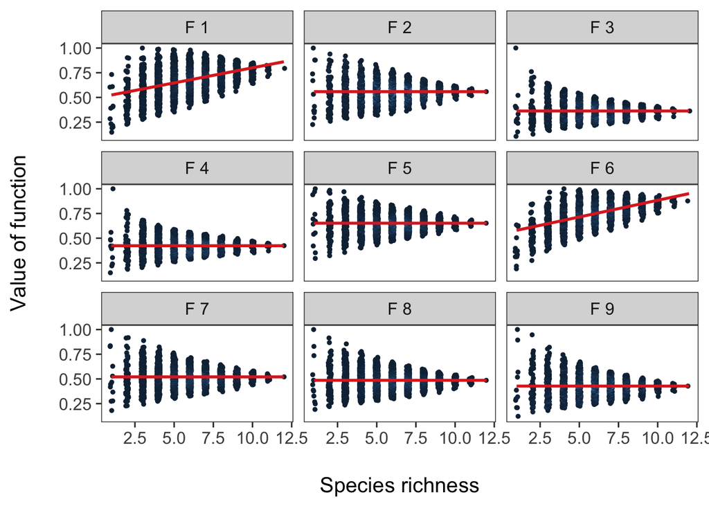

```r
AvFunc_long <- gather(AvFunc[, -c(1:specnum)], Function, FuncVal, -Richness)

SingleFunc_comp <- AvFunc_long %>%
  mutate(FuncVal = round(FuncVal,3)) %>%
  group_by(Richness, Function, FuncVal) %>%
  summarize(n = n()) %>%
  ggplot(., aes(x=Richness, y=FuncVal, colour = n))+
  geom_point( size = 1, position = position_jitter(width = 0.1))+
  facet_wrap(~Function)+
  theme_bw(base_size=15)+
  stat_smooth(data = AvFunc_long, aes(x = Richness, y = FuncVal), method="lm", colour = "#de2d26") +
  xlab("\nSpecies richness") +
  ylab("Value of function\n") +
  theme(panel.grid = element_blank(), legend.position = "none")

SingleFunc_comp
```

### Average approach for multifunctionality

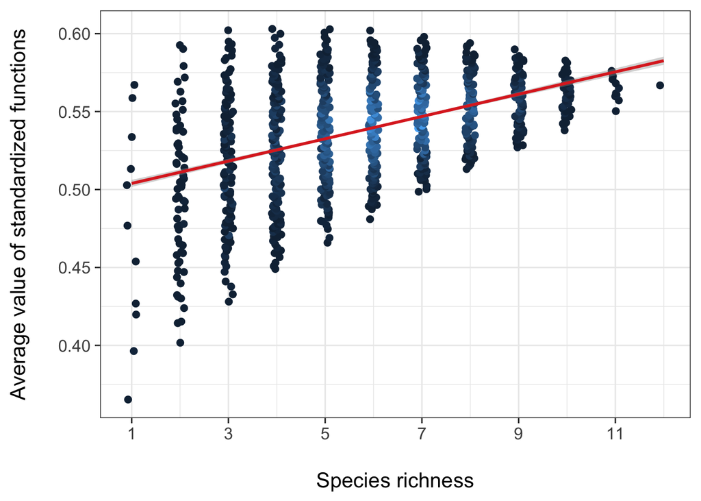

```r
# add averaged multifunctional index
AvFunc$meanFunction <- rowMeans(AvFunc[,func.names])

#plot it
AverageFunc_comp <-
  AvFunc %>%
  select(Richness, meanFunction) %>%
  mutate(meanFunction = round(meanFunction,3)) %>%
  group_by(Richness, meanFunction) %>%
  summarize(n = n()) %>%
  ggplot(., aes(x=Richness, y=meanFunction, colour = n))+
  geom_point(size = 2, position = position_jitter(width = 0.1))+
    theme_bw(base_size=15)+
    stat_smooth(data = AvFunc, aes(x = Richness, y = meanFunction), method="lm", colour = "#de2d26") +
    xlab("\nSpecies richness") +
    ylab("Average value of standardized functions\n")+
  theme(legend.position = "none")+
   # scale_y_continuous(limits = c(0.25,0.75))+
    scale_x_continuous(breaks = seq(1,15,2))

AverageFunc_comp
```

### new multifunctionlity metric

*code copied and adapted from multifunc_new.Rmd*

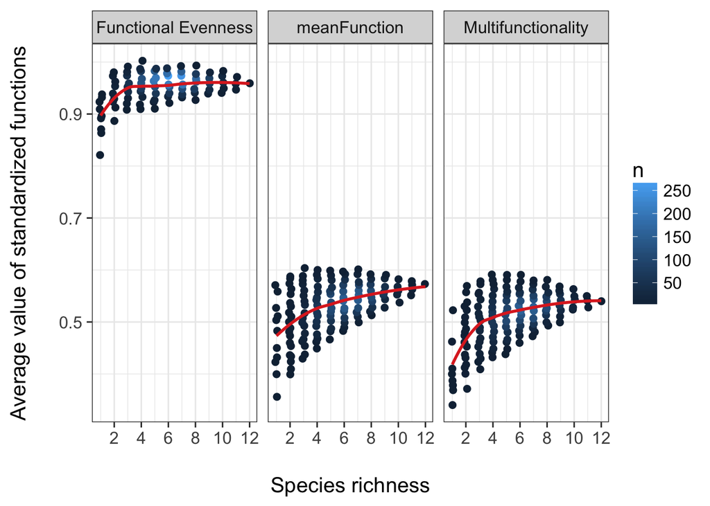

```r
#now evenness
AvFunc[["Functional Evenness"]] <- AvFunc %>% funcEven(func.names)

#Now our multifunctionality metric - I could have
#done this as a product, but I'm guessing people will want a function
AvFunc$Multifunctionality <- AvFunc %>% getMF(func.names)

Multifunc_new_comp <-
  AvFunc %>%
  select(Richness, meanFunction, `Functional Evenness`, Multifunctionality) %>%
  gather(index, value, -Richness) %>%
  mutate(value = round(value, 2)) %>%
  group_by(value, Richness, index) %>%
  summarise(n = n()) %>%
  ggplot(., aes(x=Richness, y=value, colour = n))+
  geom_point(size = 2,
             position = position_jitter(width = 0.1))+
    theme_bw(base_size=15)+
    stat_smooth( colour = "#de2d26", se = F) +
    facet_wrap(~index)+
    xlab("\nSpecies richness") +
    ylab("Average value of standardized functions\n")+
 # theme(legend.position = "none")+
   # scale_y_continuous(limits = c(0.25,0.75))+
    scale_x_continuous(breaks = seq(0,12,2))

Multifunc_new_comp
```